# Plotting examples using ggplot2

This script shows different examples for plotting behavioral data. Specifically, this example uses learning data that was published in:  
McHaney, J. R., Schuerman, W. L., Leonard, M. K., & Chandrasekaran, B. (2023). Transcutaneous Auricular Vagus Nerve Stimulation Modulates Performance but Not Pupil Size During Nonnative Speech Category Learning. *Journal of Speech, Language, and Hearing Research, 66*(10), 3825–3843. https://doi.org/10.1044/2023_JSLHR-22-00596  
This script was written by Jacie R. McHaney on April 10, 2024

# Load libraries and read in data

If you haven’t downloaded the libraries listed below, be sure to run the following command: `install.packages('libraryneeded')` where `libraryneeded` is replaced with `tidyverse`,`rstatix`, or `ggplot2`. You will run this command in the Console.

```r
rm(list = ls()) #this clears your global environment

library(tidyverse) #really helpful library for wrangling data
library(rstatix) #awesome library for statistics
```

```r
library(ggplot2) #plotting library

#replace the follwing path destination with where you've downloaded you data to.
path <- '/Users/myk4766/Library/CloudStorage/OneDrive-NorthwesternUniversity/NU/VNS3/OSF_data'

#read in csv file of data
fn <- 'behavior_data.csv' #this is your file name
data<- read.csv(paste(path, '/', fn, sep = '')) #now read it in
```

Take a quick look at the data.

```r
head(data)
```

|  | subj | block | runTrial | wav | syllable | speaker | correctanswer_tone | response | RT | condition | acc |
| --- | --- | --- | --- | --- | --- | --- | --- | --- | --- | --- | --- |
| 1 | 3101 | 1 | 1 | di4-iN.wav | di | i | 4 | 1 | 0.9723548 | Hard | 0 |
| 2 | 3101 | 1 | 2 | bu1-iN.wav | bu | i | 1 | 1 | 0.6170211 | Hard | 1 |
| 3 | 3101 | 1 | 3 | mi1-iN.wav | mi | i | 1 | 3 | 0.7894112 | Hard | 0 |
| 4 | 3101 | 1 | 4 | mi4-aN.wav | mi | a | 4 | 4 | 0.3652458 | Hard | 1 |
| 5 | 3101 | 1 | 5 | mi3-iN.wav | mi | i | 3 | 3 | 0.3340632 | Hard | 1 |
| 6 | 3101 | 1 | 6 | lu1-iN.wav | lu | i | 1 | 1 | 0.3348105 | Hard | 1 |

Now try to understand what each column if comprised of:

```r
summary(data)
```

```
##       subj          block      runTrial          wav
##  Min.   :3101   Min.   :1   Min.   :  1.00   Length:8000
##  1st Qu.:3111   1st Qu.:2   1st Qu.: 50.75   Class :character
##  Median :3122   Median :3   Median :100.50   Mode  :character
##  Mean   :3122   Mean   :3   Mean   :100.50
##  3rd Qu.:3132   3rd Qu.:4   3rd Qu.:150.25
##  Max.   :3142   Max.   :5   Max.   :200.00
##    syllable           speaker          correctanswer_tone    response
##  Length:8000        Length:8000        Min.   :1.00       Min.   :1.000
##  Class :character   Class :character   1st Qu.:1.75       1st Qu.:1.000
##  Mode  :character   Mode  :character   Median :2.50       Median :2.000
##                                        Mean   :2.50       Mean   :2.479
##                                        3rd Qu.:3.25       3rd Qu.:3.000
##                                        Max.   :4.00       Max.   :4.000
##        RT            condition              acc
##  Min.   : 0.00194   Length:8000        Min.   :0.0000
##  1st Qu.: 0.37080   Class :character   1st Qu.:0.0000
##  Median : 0.56006   Mode  :character   Median :1.0000
##  Mean   : 0.99362                      Mean   :0.5248
##  3rd Qu.: 1.00053                      3rd Qu.:1.0000
##  Max.   :35.16637                      Max.   :1.0000
```

In this task, subjects completed a learning task across 5 blocks of learning (`block`) with 40 trials (`runTrial`) per block, where they head a tone (labeled as `correctanswer_tone` and had to categorize into 1 of 4 categories (participant response = `response`. There were two participants groups, labeled as `condition` in the data file.  
Now that you’re familiar with the data organization, let’s start plotting to get an idea of how it looks.

# Plots

First, get average accuracy per subject per block of learning

```r
acc.data <- data %>% # short cut to inserting a "pipe": Command Shift M (Ctrl Shift M on PC)
  group_by(subj,block,condition) %>%
  get_summary_stats(acc, type = 'mean') %>% #this is a really cool function from rstatix
  select(-c(variable, n)) %>%  #remove irrelevant columns
  rename(Accuracy = mean) #rename the mean to accuracy
```

Now each subject has an average accuracy per block in the task, split by condition

## Plot accuracies with a line graph

For plotting, my preference is to send each command of ggplot into a `p` variable. then `p <- p +` so that if I want to make quick changes, I can easily comment out the line that I want gone without doing a ton of work to the code.

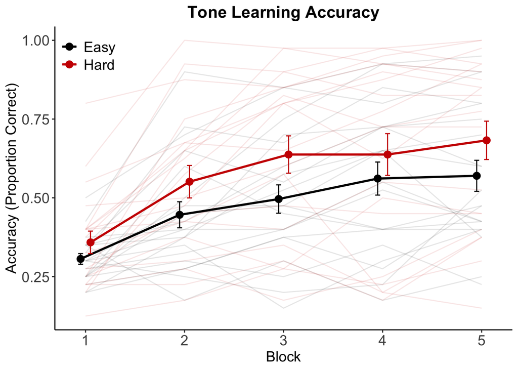

```r
p <- ggplot(acc.data, aes(x = block, y = Accuracy, group = condition, color = condition))
p <- p + geom_line(aes(group = subj), linewidth = .5, alpha = .1) #create individual subject lines with a .5 width and 10% visibility
p <- p + stat_summary(fun.data = 'mean_se', geom = 'line', linewidth = 1, position = position_dodge(width = .2)) #average lines
p <- p + stat_summary(fun.data = 'mean_se', geom = 'errorbar', linewidth = .5, width = .1, position = position_dodge(width = .2)) #error bars
p <- p + stat_summary(fun.data = 'mean_se', geom = 'point', size = 3, position = position_dodge(width = .2)) #average points
p <- p + scale_color_manual(values = c('#000000','#CC0000')) #assign whatever colors you want per group
p <- p + theme_bw() #this removes grid lines
p <- p + theme(panel.border = element_blank(), #panel commands remove major boxes
               panel.grid.major = element_blank(),
               panel.grid.minor = element_blank(),
               axis.line = element_line(colour = 'black'), #color of axis lines
               axis.text = element_text(size = 14),
               axis.title = element_text(size = 14),
               legend.text = element_text(size = 14),
               legend.title = element_blank(), #remove legend title and background box below
               legend.background = element_blank(),
               legend.position = c(0,1), #move legend to a specific position with this line and one below (numbers need to be the same in each)
               legend.justification = c(0,1),
               plot.title = element_text(hjust = .5, face = 'bold', size = 16)) #center plot title, bold it
p <- p + ylab('Accuracy (Proportion Correct)') + xlab('Block') #axis labels
p <- p + ggtitle('Tone Learning Accuracy') #plot title
print(p) #show me the plot
```

```r
fname <- paste(path, '/accuracies.png',sep = '') #define figure name
ggsave(fname, width = 4, height = 3, units = 'in') #save it with dimensions that you want
```

## Box plot

As an example, let’s highlight accuracies just in block 5 between groups

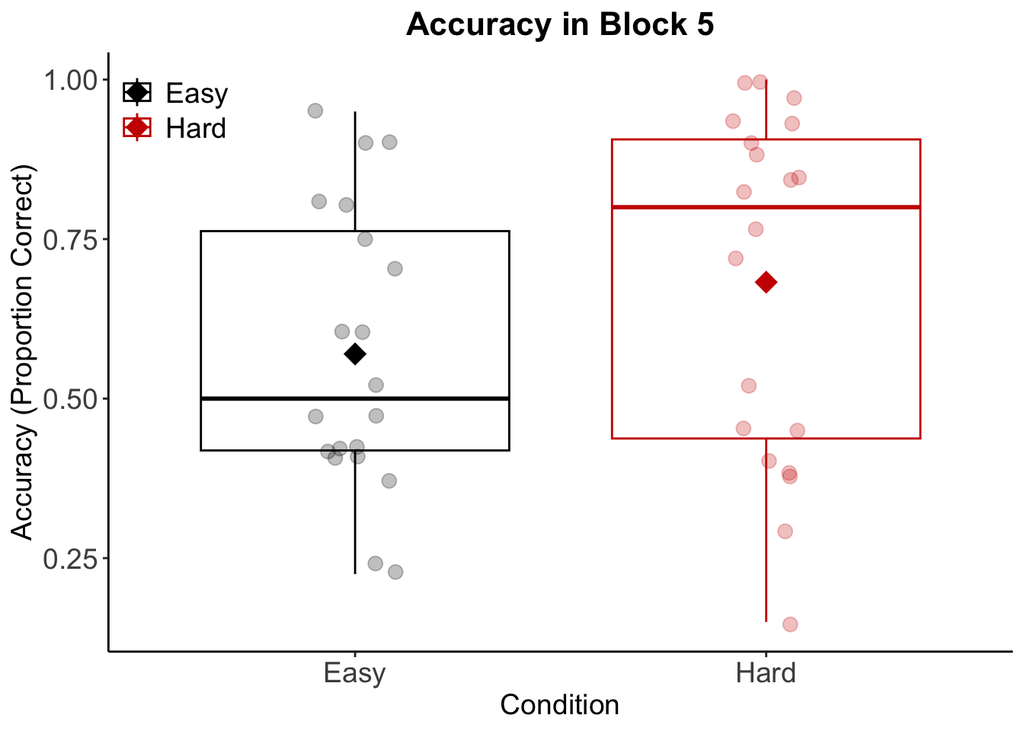

```r
#filter to just block 5 (last block)
b5 <- acc.data %>%
  subset(block == 5)

#plot
p <- ggplot(b5, aes(x = condition, y = Accuracy, group = condition, color = condition))
p <- p + geom_boxplot(linewidth = .5)
p <- p + geom_point(size = 3, alpha = .25, position = position_jitter(width = .1)) #overlay individual subject points and jitter them to show variability
p <- p + stat_summary(fun.data = 'mean_se', geom = 'point', size = 5, shape = 18, aes(fill = condition)) #mean performance in each condition with a diamond point
p <- p + scale_color_manual(values = c('#000000','#CC0000')) #assign whatever colors you want per group
p <- p + theme_bw() #this removes grid lines
p <- p + theme(panel.border = element_blank(), #panel commands remove major boxes
               panel.grid.major = element_blank(),
               panel.grid.minor = element_blank(),
               axis.line = element_line(colour = 'black'), #color of axis lines
               axis.text = element_text(size = 14),
               axis.title = element_text(size = 14),
               legend.text = element_text(size = 14),
               legend.title = element_blank(), #remove legend title and background box below
               legend.background = element_blank(),
               legend.position = c(0,1), #move legend to a specific position with this line and one below (numbers need to be the same in each)
               legend.justification = c(0,1),
               plot.title = element_text(hjust = .5, face = 'bold', size = 16)) #center plot title, bold it
p <- p + ylab('Accuracy (Proportion Correct)') + xlab('Condition') #axis labels
p <- p + ggtitle('Accuracy in Block 5') #plot title
print(p) #show me the plot
```

```r
fname <- paste(path, '/accuracies_boxplot.png',sep = '') #define figure name
ggsave(fname, width = 4, height = 3, units = 'in') #save it with dimensions that you want
```